# M2: Introduction to Hidden Markov Models

Day 5 — Behavior Analysis Part 2

Animal Movement Analyses for Ecologists | SYSU Shenzhen, July 2026

12 August 2026

# Learning Objectives

By the end of this module you will be able to:

1. Learn the analysis workflow for fitting hidden Markov models with [momentuHMM](https://cran.r-project.org/web/packages/momentuHMM/index.html)
2. Practice investigation of impact of continuous covariates on state transition probabilities
3. Learn how to interpret the output from HMMs
4. Practice methods for visualizing HMM output both spatially and graphically

**Packages used:** `momentuHMM`, `lubridate`, `tidyverse`

# Introduction

> Many thanks to Drs. Joseph Kolowski and Autumn-Lynn Harrison for assistance in developing this module

There are three main packages for fitting discrete-time hidden Markov models (HMMs) in [R](https://cran.r-project.org/): [moveHMM](https://cran.r-project.org/web/packages/moveHMM/index.html), [momentuHMM](https://cran.r-project.org/web/packages/momentuHMM/index.html), and [hmmTMB](https://cran.r-project.org/web/packages/hmmTMB/index.html). These packages are very similar (i.e., the syntax is the same) and are maintained by the same architects, Theo Michelot and Brett McClintock. The difference between the packages are the complexity of models that can be fitted. [MoveHMM](https://cran.r-project.org/web/packages/moveHMM/index.html) is the most basic of the three packages, limited to estimating 2 or so biologically-meaningful behavior states from the data stream (i.e,. step length, turning angle). It offers a good starting point to HMMs. [MomentuHMM](https://cran.r-project.org/web/packages/momentuHMM/index.html) allows for the incorporation of auxiliary biotelemetry information (e.g., from pressure, conductivity, heart rate, or motion sensors), which results in less restrictions on the constraints to parameters and provides for greater possibilities in estimating additional behavioral states. [HmmTMB](https://cran.r-project.org/web/packages/hmmTMB/index.html) adds some very nice functionality, especially related to estimating initial starting values and inclusion of random effects.

In this exercise, we will fit HMMs with the [momentuHMM](https://cran.r-project.org/web/packages/momentuHMM/index.html) package to assess changes in wildebeest behavior. We will continue to use the dataset from previous exercises that has been cleaned and subset to the Athi-Kaputiei Plains in Kenya. Remember that the data have been re-sampled to a 3-hour fix interval. We’ll investigate the role of temperature and time of day on the movement behaviors of wildebeest, but many other environmental variables (e.g., Anthropogenic Disturbance) could be added to further our understanding on potential impacts to animals.

The code provided is based on exercises developed by Joe Kolowski at the Smithsonian-Mason School of Conservation, with sections modified from the [momentuHMM](https://cran.r-project.org/web/packages/momentuHMM/index.html) guide.

## 1. Setup

Similar to other modules, we will load the required libraries and remove everything held in [R’s](https://cran.r-project.org/) memory.

```r
# Remove items from memory/clean your workspace
rm(list=ls())

# You may need to install these packages first
#install.packages('momentuHMM', 'lubridate', 'tidyverse')

# Load libraries
library(momentuHMM)
library(lubridate)
library(tidyverse)
```

### 1.1 Data Import & Formatting

Load the cleaned wildebeest dataset from the previous exercise. Before doing so, there are a few things to note:

- Data for analysis should have negligible location error. If you are working with high levels of error (common to marine species that are being tracked by Argos) or if data are irregular, you should likely process it first before analysis. For example, you may try a state space approach, such as [crawl](https://cran.r-project.org/web/packages/crawl/index.html) or [aniMotum](https://ianjonsen.github.io/aniMotum/articles/Overview.html), or use [ctmm](https://cran.r-project.org/web/packages/ctmm/index.html) to correct for the GPS error and then use `predict()` to create the most likely path of your animal for incorporation in analysis. If you are simulating large amounts of the trajectory to fill in portions of the trajectory where data are missing, it is recommended to create multiple simulated trajectories so that uncertainty can be quantified. [MomentuHMM](https://cran.r-project.org/web/packages/momentuHMM/index.html) has techniques for doing so and also provides a 2-stage imputation approach when data are temporarily-irregular or subject to measurement error. See the `help()` for more information.
- Data should be analyzed in an ordered sequence (Neither [moveHMM](https://cran.r-project.org/web/packages/moveHMM/index.html), [momentuHMM](https://cran.r-project.org/web/packages/momentuHMM/index.html), or [hmmTMB](https://cran.r-project.org/web/packages/hmmTMB/index.html) recognizes the time as a sequence. Use `arrange()` to order by the time field.
- The animal id column must be named “ID”.
- When analyzing the data as UTMs, converting the coordinates to km by dividing by 1000 is helpful in estimating model parameters.

```r
# Read the dataset into R, selecting the necessary columns (x, y, date, id) for analyses.
# We will also grab the temperature column, convert the x/y values to km (e.g., x/1000), and create an hour field.
# We many also want to summarize results by the sex of each animal. Since sex is not included in our dataset, we can join this information from a reference table that we will import.

# Load dataset
load("Data/WB_3h_resampled.rdata")

# Read in Reference dataset
WB.ref <- read_csv("data/WB_ref.csv")

# Here, we'll do a little cleaning of the reference dataset, join to the 3h tracking dataset, and prepare the file for further analysis.
WB.data <- WB.ref %>%
  #filter(study_site == "Athi-Kaputiei Plains") %>%
  mutate(id = as.factor(as.character(individual_local_identifier)), # Make format the same as trk_resampled_3h field
         sex = as.numeric(as.factor(sex))) %>%
  select(
    id,
    sex
  ) %>%
  right_join( # Keep all from trk_resampled_3h
    trk_resampled_3h,
    by = join_by(id)
  ) %>%
  # Now, arrange the dataframe, manipulate the columns, and select the fields of interest
  arrange(id, t_) %>% # Not really necessary, but always good practice to make sure the data are in correct order
  select(x = x_,
         y = y_,
         t = t_,
         ID = id,
         temp,
         sex) %>%
  mutate(hour = hour(t),
         x = x/1000,
         y = y/1000,
         temp = as.numeric(temp)
         ) %>%
  # Convert to dataframe
  as.data.frame()

# Clean up your environment
rm(trk_resampled_3h, WB.ref)
```

## 2. Create Move Object

Now that we have imported the data, we will use the function `prepData` to prepare the data for analyses and create a `momenuHMMData` object. If our data were provided as raw lat/long values, we could still import the data, but we would need to set the type = “LL” (default). We can specify the coordinate and covariate names explicity. See `help(prepData)` for additional information.

**Note** [MomentuHMM](https://cran.r-project.org/web/packages/momentuHMM/index.html) package only works with longitude/latitude and UTM projected data.

```r
# Subset the dataset using the slice command so that analyses run more quickly.
# Only for testing
# WB.data <- WB.data %>%
#   group_by(ID) %>%
#   slice_head(prop = 0.20) %>%
#   as.data.frame()

# Create Object
WB.move <- prepData(WB.data,
                    type = "UTM",
                    # Specify coordinate names
                    coordNames = c("x","y"),
                    covNames = c("temp", "hour"))
```

### 2.1 Object Summary

The [MomentuHMM](https://cran.r-project.org/web/packages/momentuHMM/index.html) package includes a number of functions to help summarize the content of the `momentuHMMData` object. We’ll see that we have movement data for all 12 wildebeest (a good check!). We also see from above that the format is a data.frame, making it relatively easy to modify our object if we need to. Also notice that the function `prepData` created two additional columns in our dataset, “step (steplength)” and “angle (turning angle)”. These are the two fields that will be used in all future modeling steps. The plot function will show the movement trajectory and include plots of the steplengths and turning angles.

```r
# Summarize the object
summary(WB.move)
```

```
## HMM data for 12 individuals:
##
## Karbolo -- 2967 observations
## Kikaya -- 5276 observations
## Kiranto -- 5924 observations
## Laingoni -- 3823 observations
## Ne Mpaash -- 3659 observations
## Noontare -- 5317 observations
## Ntishya -- 5847 observations
## Ole Nagol -- 549 observations
## Paita -- 5494 observations
## Peria -- 5868 observations
## Sawani -- 1764 observations
## Sotua -- 2214 observations
##
##
## Data summaries:
##
##       step           angle
##  Min.   : 0.00   Min.   :-3.1416
##  1st Qu.: 0.11   1st Qu.:-1.5736
##  Median : 0.24   Median : 0.0148
##  Mean   : 0.44   Mean   : 0.0046
##  3rd Qu.: 0.50   3rd Qu.: 1.5899
##  Max.   :23.39   Max.   : 3.1416
##  NA's   :12      NA's   :26
```

```r
# What are the column headings included in this move object?
names(WB.move)
```

```
## [1] "ID"    "step"  "angle" "t"     "sex"   "x"     "y"     "temp"  "hour"
```

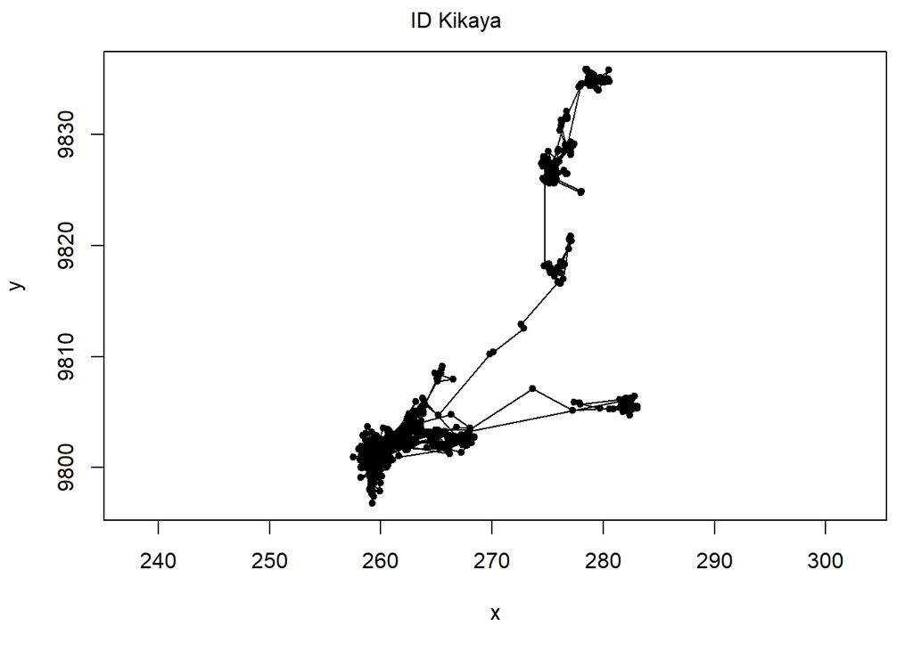

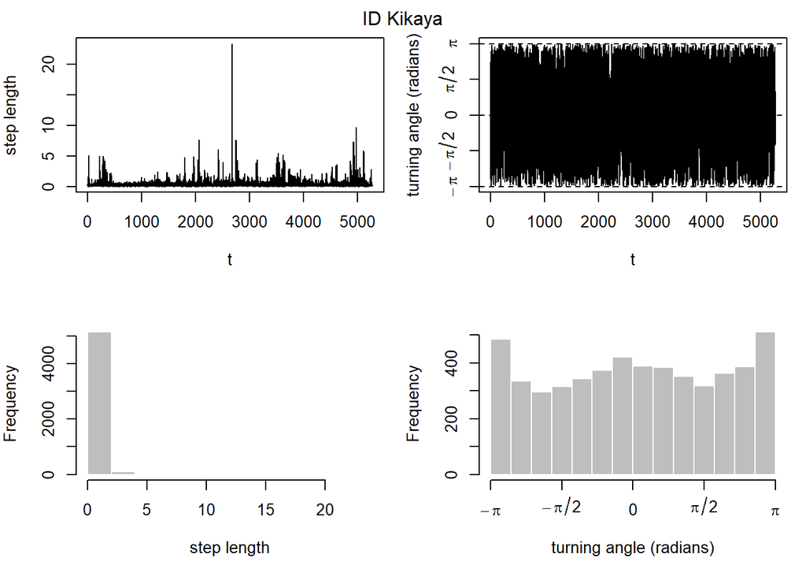

```r
# We can plot all animals together. Please try!
# plot(WB.move,
#      compact = TRUE, # Make sure you specify compact = TRUE. If you don't specify, each plot will be drawn separately, which can be tedious
#      ask = FALSE)

# Or, each animal separately
# unique(WB.move$ID) # We can always query the dataframe for the names of each animal.
plot(WB.move[WB.move$ID == "Kikaya",],
     ask = FALSE)
```

```r
# We can also investigate the steplength and turning separately, using standard R commands
# Note that these summaries are for all animals together
# hist(WB.move$step)
# summary(WB.move$step)
# quantile(WB.move$step,
#          probs = 0.90,
#          na.rm = TRUE)
# hist(WB.move$angle)
```

## 3. Fitting a Hidden Markov Model

To begin modeling, we need to set starting values for all relevant estimable parameters. This is arguably the most challenging aspect of fitting a HMM. [MomentuHMM](https://cran.r-project.org/web/packages/momentuHMM/index.html) includes a number of functions, including `GetPar`, `getPar0`, `getParDM`, and `checkPar0`, to help with specification of starting values. Use the `help()` function for tips and tricks. A short guide is also provided with the [moveHMM](https://cran.r-project.org/web/packages/moveHMM/index.html) package that provides a series of recommendations to select initial parameter values. See [A short guide to choosing initial parameter values for the estimation in moveHMM](https://cran.r-project.org/web/packages/moveHMM/vignettes/moveHMM-starting-values.pdf), for more information. [HmmTMB](https://cran.r-project.org/web/packages/hmmTMB/index.html) also contains a function (i.e., `suggest_initial()`) that can help in providing or suggesting initial starting values based on your data. Investigating the movements of your animals and being clear about the behaviors of interest (as opposed to simply data mining) will help with informing what these starting values should be.

As a starting point, we will fit a 2-state model, without specifying covariates to influence behavioral transitions (i.e., a NULL model). We will then build a few, slightly more complex models where the covariate(s) inform the transition from one state to the next. To do so, we must first specify the number of behavioral states we want to identify, which require us to provide initial values for the vectors stepPar0 (for the step distributions) and anglePar0 (for the angle distributions). We then need to select a statistical distribution that best describe each of these vectors.

[MomentuHMM](https://cran.r-project.org/web/packages/momentuHMM/index.html) includes a variety of distributions. We will use the gamma distribution to describe steplengths (because it is a strictly positive distribution) and the von Mises distribution for turning angles. Other common distributions for steplength include Weibull (“weibull”), exponential (“exp”), and log-normal (“lnorm”). Wrapped-Cauchy (“wrpcauchy”) is commonly used as an alternative distribution to describe turning angles. You can experiment with these distributions (and others) to find the best fitting model.

### 3.1 Set Starting Values

The “gamma” distribution requires us to set two (and potentially three) parameters describing the steplengths of our animals: mean and standard deviation. The third potential parameter, called zero mass, is required if we have steplengths that are exactly zero. This parameter accounts for zero inflation in the gamma distribution. The “von Mises (vm)” distribution requires us to set two parameters describing the turning angles. These are the mean turning angle and the angle concentration, which reflects the variance in the turning angle distribution.

Here, we will choose initial values that correspond to commonly observed patterns in 2-state HMMs for animal movement data, with state 1 involving relatively short steps and many turns (small mean steplength and large mean turning angle - Slow tortuous movements) and state 2 involving longer steps and fewer turns (large mean steplength and small mean turning angle - Fast directed Movements). For ungulates, this is often referred to as an “area restricted search”, with animals switching from an *“encamped”* behavioral state to an *“exploratory”* behavioral state. Once again, this is a good opportunity to look at the movements of your data to identify items of interest that we might be able to identify in the data. Below, we investigate the data by summarizing the steplengths and turning angles with a histogram.

**Note:** To ensure starting values do not overly impact results, some authors will repeat model fitting with a range of starting values. This allows one to test the sensitivity of results to starting value decisions.

```r
# Let's first determine if we have any step lengths of 0. If yes, we need to include a zero mass parameter. If no, setting a zeromass value is not necessary.

# The slice_min() command allows us to view the 10 lowest values of the steplength parameter. It's a convenient function to order by the minimum steplengths.
slice_min(WB.move,
          order_by = step,
          n = 10)
```

```
##          ID         step      angle                   t sex        x        y
## 1   Kiranto 0.0000000000         NA 2011-03-14 06:00:00   2 274.4271 9820.839
## 2     Sotua 0.0002030961 -1.8505333 2011-01-26 09:00:00   2 267.7008 9842.426
## 3  Noontare 0.0002190408  1.2641310 2012-02-13 09:00:00   1 262.0326 9840.241
## 4   Ntishya 0.0002386294  2.6454262 2010-10-27 09:00:00   1 277.1406 9803.755
## 5   Ntishya 0.0002589569  2.2455035 2010-12-18 00:00:00   1 276.5636 9804.797
## 6   Kiranto 0.0002590682 -3.0416837 2012-09-22 09:00:00   2 274.2041 9820.862
## 7   Kiranto 0.0003723930 -0.8996080 2011-03-24 18:01:00   2 274.2146 9820.770
## 8   Kiranto 0.0004061411 -0.7387222 2010-10-17 21:00:00   2 274.3063 9820.626
## 9    Kikaya 0.0004080940  0.7955464 2011-07-17 09:00:00   1 259.7285 9801.829
## 10    Sotua 0.0004081535 -2.4032734 2011-06-15 09:00:00   2 262.6243 9839.980
##    temp hour
## 1    26    6
## 2    28    9
## 3    28    9
## 4    28    9
## 5    15    0
## 6    27    9
## 7    22   18
## 8    20   21
## 9    28    9
## 10   26    9
```

```r
# You could also query the dataset and summarize numerically
whichzero <- which(WB.move$step == 0)

# Calculate the proportion of steps of length zero
(prop.0 <- length(whichzero)/nrow(WB.move))
```

```
## [1] 2.053304e-05
```

Since we do have a step = 0 for ‘Kiranto’, we need to include a zero mass parameter for the gamma distribution.

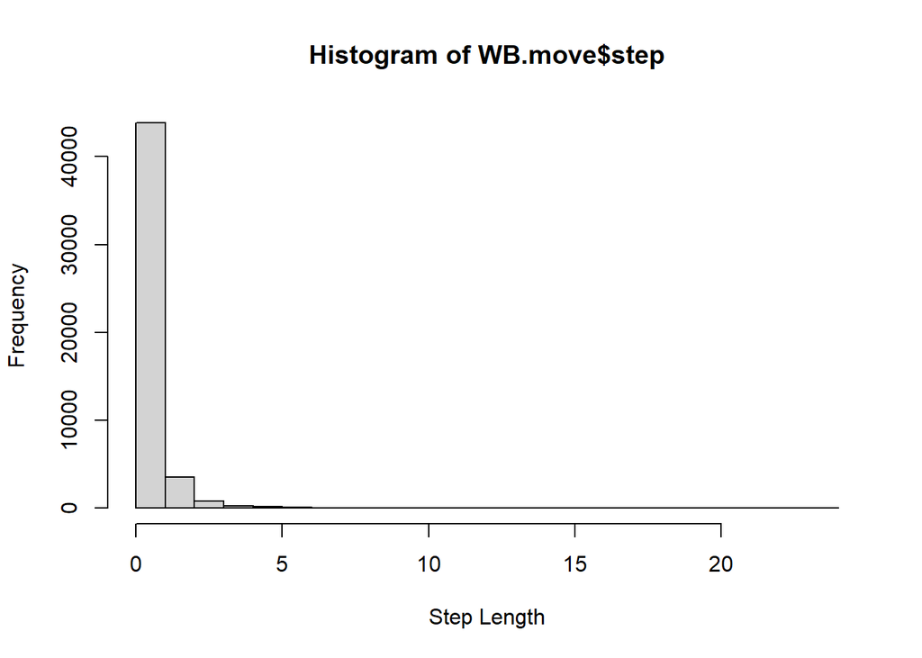

```r
# Check distributions
hist(WB.move$step, xlab="Step Length")
```

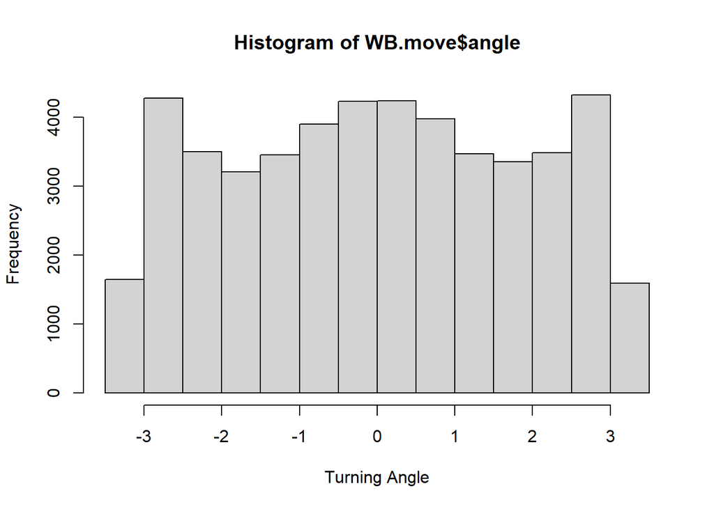

```r
hist(WB.move$angle, xlab="Turning Angle")
```

```r
# Define Starting Values
# ************************************
# For Step Length (gamma distribution): c(mean1, mean2, sd1, sd2, zeromass1, zeromass2)
# Mean
mu0 <- c(0.1, 1)

# SD
sigma0 <- c(1, 1)

# Zero Mass
zeromass0 <- c(prop.0, prop.0)

# Combine together
stepPar0 <- c(mu0, sigma0, zeromass0)

# For Turning Angle (von mises distribution): c(mean1, mean2, concentration1, concentration2)
# In radians, pi, or 3.14 represents 180 degrees.
# We expect the concentration to be larger when directed movement (mean = 2) occurs
anglePar0 <- c(pi, 0, 1, 10)
```

### 3.2 Model Fitting

We will now use the function `fitHMM` to fit our NULL model. We specify the properly formatted object, define the number of states, input our starting values, and identify our steplength and turning angle distributions. Since this is our NULL model, we assume that no covariates influence behavioral transitions between states. We specify the NULL using standard regression formula notation (i.e., ~ 1).

The model summary provides a detailed numeric output, including the mean steplength from each predicted state and the standard deviation. We will see that state 1 has a much smaller steplength (~ 285m) than state 2 (~ 708m). For turning angle means, we also will see that the mean of state 2 is much closer to 0. This would indicate continued or correlated movement in roughly the same direction (i.e., directed movement). The mean turning angle for state 1 is closer to `pi`, indicating that the animal is moving in a much less directed way. Since we did not test a regression equation, we only have an intercept regression coefficient.

We are also provided with a matrix of predicted transitions, showing the average probability of transitioning from state 1 to state 2 (~2.7%) and state 2 to state 1 (~ 4.6%). The diagonals (the probability of remaining in each state) of the transition matrix are also very high (96-97%), fitting in with what we’d expect behaviorally. The resulting plots describe the distributions of steplengths and turning angles for our two states. Paths are colored based on the predicted state for each animal, which is very interesting.

```r
# Fit NULL model
WB.null <- fitHMM(data = WB.move,
                  nbStates = 2,
                  dist = list(step = "gamma", angle = "vm"), # Need to add these as a list
                  Par0 = list(step = stepPar0, angle = anglePar0), # Need to add these as a list
                  formula = ~ 1,
                  estAngleMean = list(angle=TRUE))

# Examining the 2-state model
WB.null
```

```
## Value of the maximum log-likelihood: -93961.07
##
##
## step parameters:
## ----------------
##               state 1      state 2
## mean     2.848552e-01 7.075510e-01
## sd       2.577854e-01 8.492607e-01
## zeromass 3.842553e-09 5.632615e-05
##
## angle parameters:
## -----------------
##                 state 1    state 2
## mean          2.9205526 -0.1640747
## concentration 0.1494596  0.1834945
##
## Regression coeffs for the transition probabilities:
## ---------------------------------------------------
##                1 -> 2    2 -> 1
## (Intercept) -3.599859 -3.022306
##
## Transition probability matrix:
## ------------------------------
##            state 1    state 2
## state 1 0.97339936 0.02660064
## state 2 0.04642826 0.95357174
##
## Initial distribution:
## ---------------------
##   state 1   state 2
## 0.4496913 0.5503087
```

### 3.3 Plotting Results

Now that we have a fitted model, we can plot the results to visualize the state predictions displayed in different colors.

```
## Decoding state sequence... DONE
```

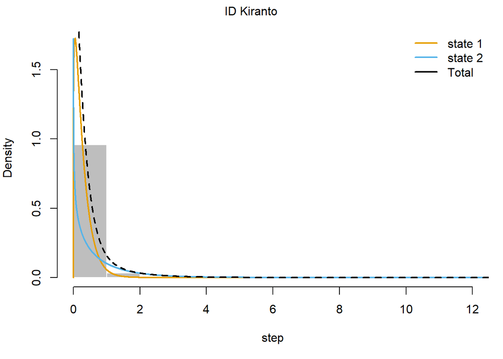

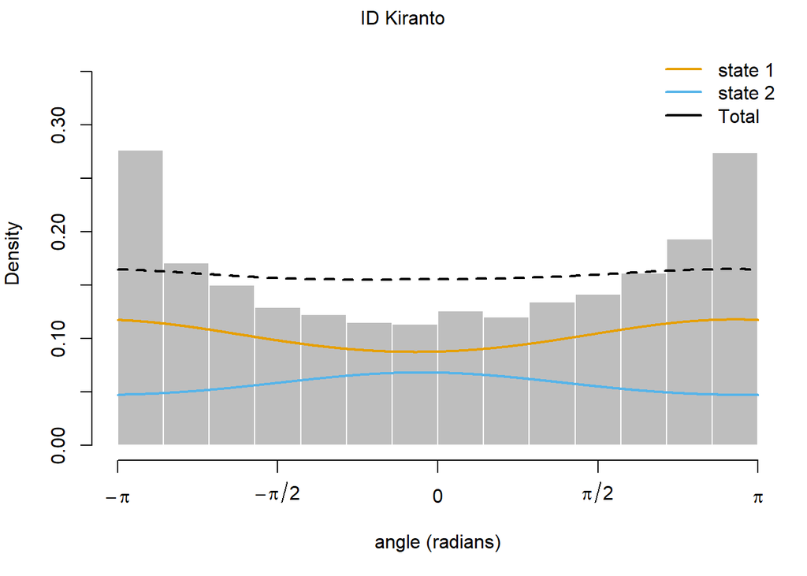

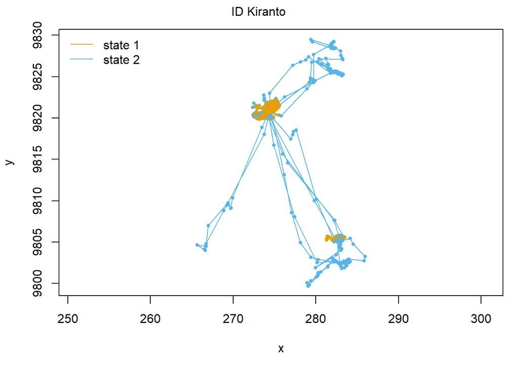

```r
# Plot the results of the predictions.
# Colored states (State 1 is orange; state 2 is blue) provide the predicted state in each trajectory.
# Plot all animals
# plot(WB.null,
#      ask = F)

# Plot individual animals
plot(WB.null,
     animals = "Kiranto",
     ask = FALSE)
```

### 3.4 State Assignments & Probabilities

To decode the state processes identified, we will implement the Viterbi algorithm using the function `viterbi()` and compute state probabilities using the function `stateProbs()`. The Viterbi algorithm computes the sequence of most probable states to have generated the observations under the fitted model. State probabilities computes the probabilities of the underlying Markov chain being in different states at each observation under the fitted model. Both state assignments provide a predicted state for each location in our dataset, allowing us to look at (for example) the proportion of time spent in each state.

#### 3.4.1 Viterbi Algorithm

```r
# Run the algorithm on the fitted model
WB.states <- viterbi(WB.null)

# Look at the state assignments. The result is just a simple vector of state assignments (class 1 or 2).
WB.states[1:25]
```

```
##  [1] 2 2 2 2 2 2 2 2 2 2 2 2 2 2 2 2 2 2 2 2 2 2 2 2 2
```

```r
# What's the proportion of time spent in each state?
prop.table(table(WB.states))
```

```
## WB.states
##         1         2
## 0.6406718 0.3593282
```

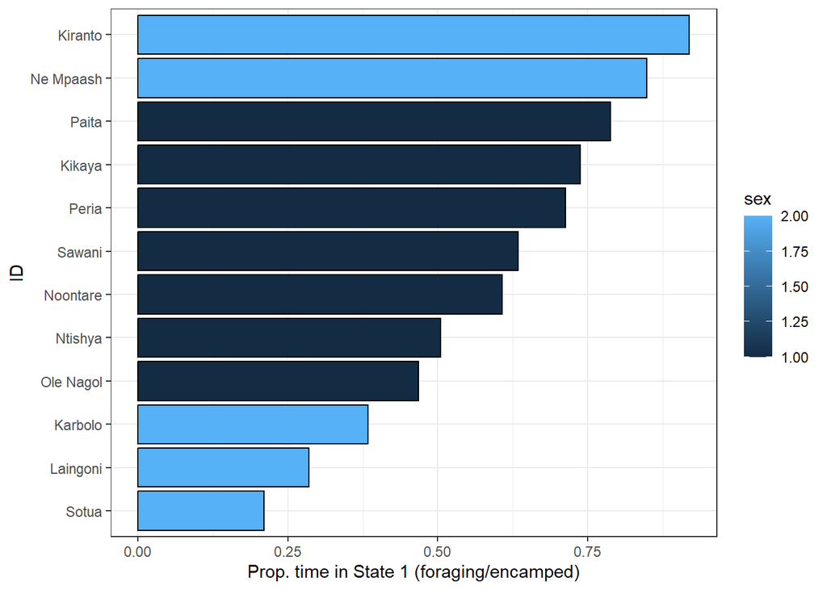

```r
# How does this differ between individuals?
# To answer this question, we need to combine the state assignments with the move object
WB.v.Props <- WB.move %>%
  mutate(state = WB.states) %>%   # create state column from WB.states (merge this with the dataframe)
  # add new column that is the total locations for each animal...used to calculate percentages
  mutate(locs = n(),
         .by = ID) %>%
  # summarize for each animal, and each state, the proportion of locations. Using the reframe() command here
  reframe(stateProp = n()/locs,
          sex = unique(sex),
          .by = c(ID, state)) %>%

  # Reduce dataset to one with just the unique rows of information.
  distinct() %>%
  arrange(ID, state)

# Graph results, color by sex to look for any potential patterns. Just a graph summary.
WB.v.Props %>%
  filter(state == 1) %>%
  mutate(ID = fct_reorder(ID,
                          stateProp)) %>%
  ggplot(aes(y = stateProp,
             x = ID,
             fill = sex)) +
  geom_col(col = "black",
           position = position_dodge()) +
  coord_flip() +
  labs(y = "Prop. time in State 1 (foraging/encamped)") +
  theme_bw()
```

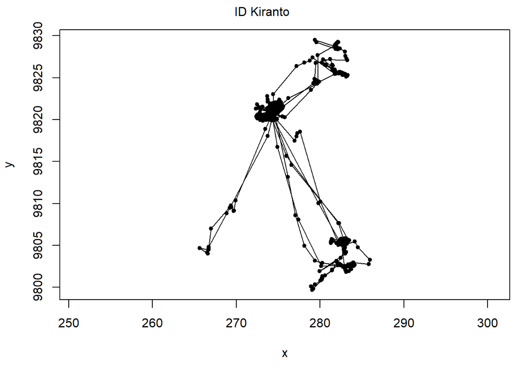

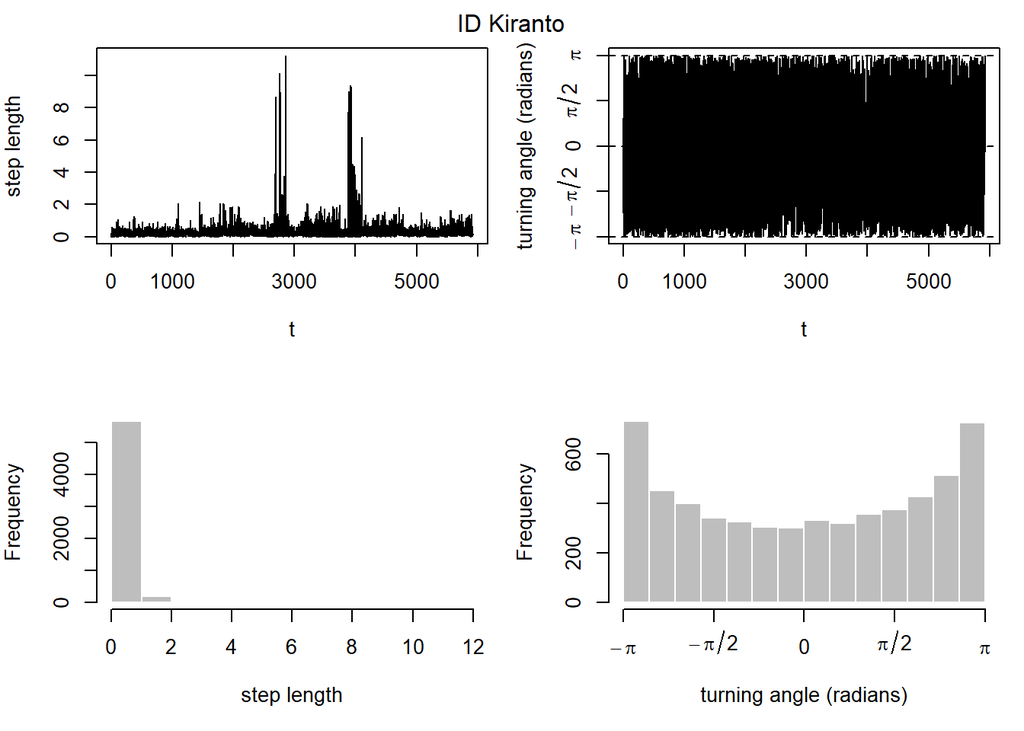

```r
# Look at Kiranto
plot(WB.move[WB.move$ID == "Kiranto",],
     ask = FALSE)
```

```r
# Interestingly, Kiranto made some long distance movements, although most of his time was spent in state 1

# How does his movement compare with Paita, for example?
# plot(WB.move[WB.move$ID == "Paita",],
#      ask = FALSE)
# A very different movement pattern, even though the amount of time in state 1 is very similar to Kiranto.
```

#### 3.4.2 State Probabilities

The `stateProbs()` function allows us to investigate the actual transitional probabilities between each point in the dataset. The output of the function is a matrix, with probabilities for each state. Values across rows should sum to 1. Note, the highest probability according to `stateProbs()` might not be the same as the state in the most probable sequence returned by the `viterbi()` algorithm. This is because the Viterbi algorithm performs “global decoding”, whereas the state probabilities are “local decoding”. For more details, see Zucchini et al. (2016).

The `plotStats()` function will plot the most likely state sequence decoded by the Viterbi algorithm (top panel), as well as both columns of the matrix of state probabilities.

```
## Decoding state sequence... DONE
## Computing state probabilities... DONE
```

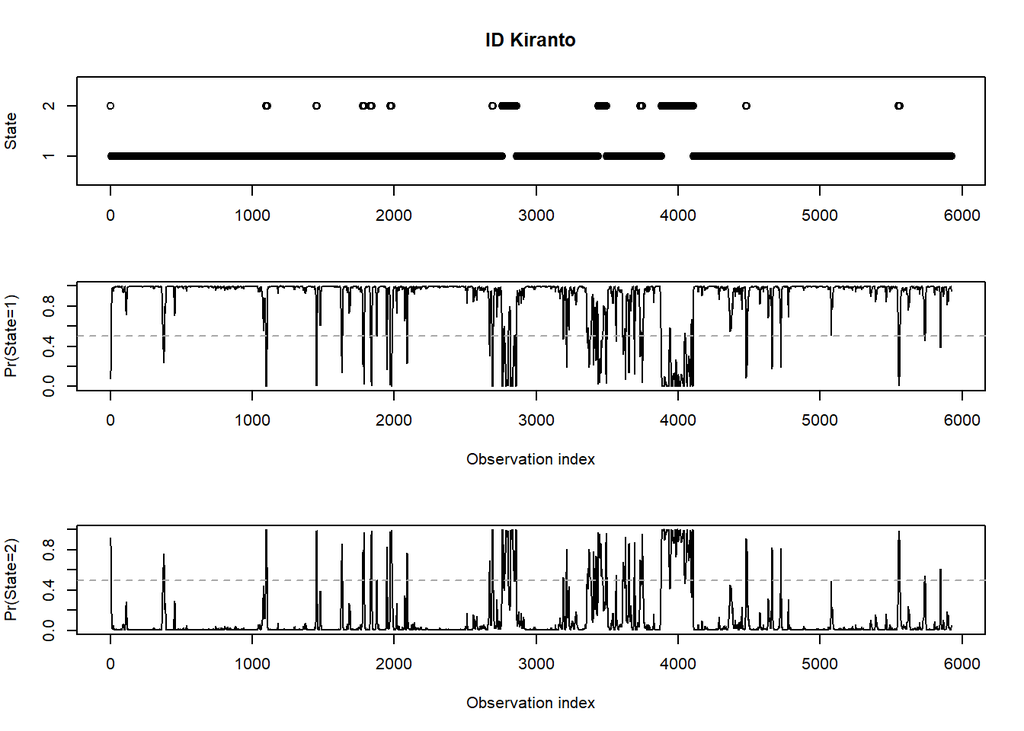

```r
# Calculate state probabilities
WB.probs <- stateProbs(WB.null)
# head(WB.probs)

# Visualize the state sequences for 1 animal
plotStates(WB.null,
          animals = "Kiranto",
          ask = FALSE)
```

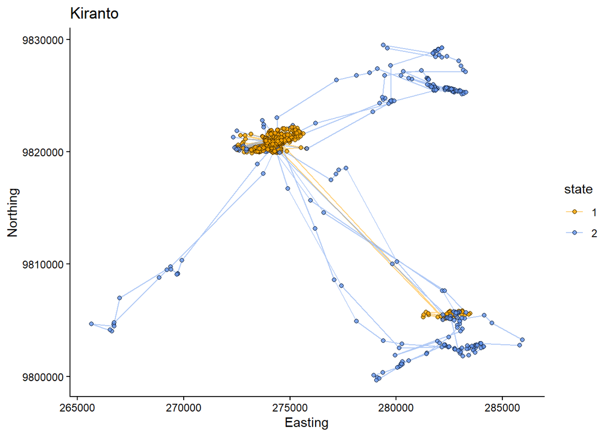

```r
# We can use the built-in plot functions (see help(plot.momentuHMM)) or create our own plots
WB.move %>%
  mutate(state = as.factor(WB.states)) %>%
  filter(ID == "Kiranto") %>%
  ggplot(aes(x = x*1000,
             y = y*1000,
             col = state,
             fill = state)) +
  geom_path(alpha = 0.5) +
  geom_point(shape = 21,
             alpha = 0.8,
             col = "black") +
  scale_fill_manual(values = c("orange",
                               "cornflowerblue")) +
  scale_color_manual(values = c("orange",
                                "cornflowerblue")) +
  theme_classic() +
  labs(x = "Easting",
       y = "Northing",
       title = "Kiranto")
```

## 4. Model Covariates

Now that we have stepped through the process of fitting a NULL model, we will investigate whether ambient temperature or time of day influences the probability of transitioning between behavioral states. We will also test if a 3-state model has more support than a 2-state model, using AIC to evaluate which model is the best fit to the data. Various other variables could be included to explain behavioral transition probabilities. For example, we might include distance to water or dense vegetation, the level of human disturbance, or season of the year. Variables must be numeric to be included in models and should vary throughout the tracking period (e.g., pregnancy status would be a suitable variable to include, but sex would not since an animals’ sex does not change). Similar to other regression-based analyses, covariates could or should be standardized (i.e., centered based on the mean and standard deviation) before fitting the model to improve numerical stability.

### 4.1 Covariate Model - Temperature

As a first example, we will fit a 2-state model with ambient temperature. We use the same starting values and parameter distributions specified previously in this script, but will add a formula `~ temp` tp add temperature as a covariate.

```r
# Fit covariate model - temperature
WB.temp <- fitHMM(data = WB.move,
                  nbStates = 2,
                  dist = list(step = "gamma", angle = "vm"),
                  Par0 = list(step = stepPar0, angle = anglePar0),
                  formula = ~ temp,
                  estAngleMean = list(angle=TRUE))

# Show model summary
WB.temp
```

```
## Value of the maximum log-likelihood: -93959
##
##
## step parameters:
## ----------------
##               state 1      state 2
## mean     2.846543e-01 7.076476e-01
## sd       2.573463e-01 8.497951e-01
## zeromass 2.344252e-10 5.627646e-05
##
## angle parameters:
## -----------------
##                 state 1    state 2
## mean          2.9219766 -0.1622851
## concentration 0.1499331  0.1841391
##
## Regression coeffs for the transition probabilities:
## ---------------------------------------------------
##                  1 -> 2      2 -> 1
## (Intercept) -2.81060655 -3.42951750
## temp        -0.03487848  0.01820192
##
## Transition probability matrix (based on mean covariate values):
## ---------------------------------------------------------------
##            state 1    state 2
## state 1 0.97347327 0.02652673
## state 2 0.04670197 0.95329803
##
## Initial distribution:
## ---------------------
## state 1 state 2
## 0.44983 0.55017
```

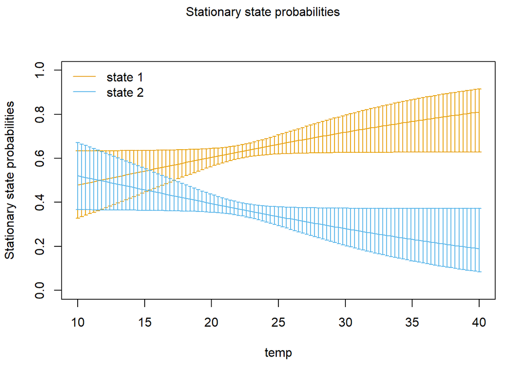

```r
# Built-in plotting function to evaluate the impacts of a covariate
plotStationary(WB.temp,
               plotCI = TRUE)
```

### 4.2 Covariate Model - Time of Day

Now let’s test a model with time of day. Hour of the day is a challenging variable to model in a regression equation because the 23rd hour is very close to the zero hour. But, if it is modeled as a regular number, this connection will be lost. The conversion below using sine and cosine allows us to model the hour of the day in a circular format. A short description of this conversation can be found [here](https://ianlondon.github.io/posts/encoding-cyclical-features-24-hour-time/). We are again using the starting parameters included in previous models and the gamma and von Mises distributions.

```r
# Fit covariate model
WB.tod.2state <- fitHMM(data = WB.move,
                 nbStates = 2,
                 dist = list(step = "gamma", angle = "vm"),
                 Par0 = list(step = stepPar0, angle = anglePar0),
                 formula = ~ cosinor(hour, period = 24),
                 estAngleMean = list(angle=TRUE))

# Summarize
WB.tod.2state
```

```
## Value of the maximum log-likelihood: -93692.73
##
##
## step parameters:
## ----------------
##               state 1      state 2
## mean     2.672415e-01 7.383699e-01
## sd       2.473513e-01 8.360025e-01
## zeromass 4.237432e-05 4.622681e-06
##
## angle parameters:
## -----------------
##                 state 1    state 2
## mean          2.9251266 -0.1522628
## concentration 0.1617998  0.2053069
##
## Regression coeffs for the transition probabilities:
## ---------------------------------------------------
##                                   1 -> 2    2 -> 1
## (Intercept)                   -103.91108 -94.19997
## cosinorCos(hour, period = 24)  -45.50936 -37.77444
## cosinorSin(hour, period = 24) -100.43327  94.05482
##
## Transition probability matrix (based on mean covariate values):
## ---------------------------------------------------------------
##             state 1      state 2
## state 1 1.00000e+00 1.625486e-44
## state 2 1.06639e-10 1.000000e+00
##
## Initial distribution:
## ---------------------
##   state 1   state 2
## 0.6144511 0.3855489
```

### 4.3 3-State Model

Now let’s expand the number of states we can identify in the tracking data while investigating the influence of the same covariate.

```r
# Starting Values - Steplengths
# *****************************
# For Step Length (gamma distribution): c(mean1, mean2, sd1, sd2, zeromass1, zeromass2, zeromass3)
# Mean
mu0 <- c(0.1, 1, 3)

# SD
sigma0 <- c(1, 1, 1)

# Zero Mass
zeromass0 <- c(prop.0, prop.0, prop.0)

# Combine together
stepPar0 <- c(mu0, sigma0, zeromass0)

# Starting values - Turning angles
# ********************************
# For turning angle (von mises): c(mean1, mean2, mean3, conc1, conc2, conc3)
anglePar0 <- c(pi, 0, 1.5, 1, 10, 5)

# Fit model
WB.tod.3state <- fitHMM(data = WB.move,
                 nbStates = 3,
                 dist = list(step = "gamma", angle = "vm"),
                 Par0 = list(step = stepPar0, angle = anglePar0),
                 formula = ~ cosinor(hour, period = 24),
                 estAngleMean = list(angle=TRUE))

# Summarize
WB.tod.3state
```

```
## Value of the maximum log-likelihood: -91884.45
##
##
## step parameters:
## ----------------
##               state 1      state 2      state 3
## mean     1.595820e-01 8.998792e-01 2.478162e-01
## sd       1.763105e-01 8.286417e-01 2.192368e-01
## zeromass 4.775312e-05 1.907633e-05 9.791469e-06
##
## angle parameters:
## -----------------
##                 state 1     state 2   state 3
## mean          3.1182028 -0.01489305 3.0195923
## concentration 0.2529251  0.28918899 0.1503607
##
## Regression coeffs for the transition probabilities:
## ---------------------------------------------------
##                                  1 -> 2      1 -> 3    2 -> 1     2 -> 3
## (Intercept)                    2.814537   13.988335 -69.59125 0.06267827
## cosinorCos(hour, period = 24) 27.994030   -7.866789  -7.43756 0.14338839
## cosinorSin(hour, period = 24) 19.167266 -114.249889  30.41812 0.66724257
##                                  3 -> 1     3 -> 2
## (Intercept)                   -85.53385  0.8887893
## cosinorCos(hour, period = 24) -89.68115 -4.2453189
## cosinorSin(hour, period = 24) 136.11659  5.4342011
##
## Transition probability matrix (based on mean covariate values):
## ---------------------------------------------------------------
##              state 1      state 2      state 3
## state 1 9.999998e-01 1.717474e-07 1.041909e-10
## state 2 3.349814e-23 4.529493e-01 5.470507e-01
## state 3 1.000000e+00 2.245999e-19 2.248308e-22
##
## Initial distribution:
## ---------------------
##    state 1    state 2    state 3
## 0.60619317 0.30413036 0.08967647
```